# Linear Regression Mini Project

Anthony Stachowitz

May 30, 2018

# Linear Regression Mini Project

# Exercise 1: least squares regression

Use the /states.rds/ data set. Fit a model predicting energy consumed per capita (energy) from the percentage of residents living in metropolitan areas (metro). Be sure to

1. Examine/plot the data before fitting the model
2. Print and interpret the model `summary’
3. `plot’ the model to look for deviations from modeling assumptions

Select one or more additional predictors to add to your model and repeat steps 1-3. Is this model significantly better than the model with /metro/ as the only predictor?

### Examine/plot the data before fitting the model

```r
states.data <- readRDS("dataSets/states.rds")
states.info <- data.frame(attributes(states.data)[c("names", "var.labels")])
tail(states.info, 8)
```

```
##      names                      var.labels
## 14    csat        Mean composite SAT score
## 15    vsat           Mean verbal SAT score
## 16    msat             Mean math SAT score
## 17 percent       % HS graduates taking SAT
## 18 expense Per pupil expenditures prim&sec
## 19  income Median household income, $1,000
## 20    high             % adults HS diploma
## 21 college         % adults college degree
```

```r
sts.eng.mtr <- subset(states.data, select = c("energy", "metro"))
summary(sts.eng.mtr)
```

```
##      energy          metro
##  Min.   :200.0   Min.   : 20.40
##  1st Qu.:285.0   1st Qu.: 46.98
##  Median :320.0   Median : 67.55
##  Mean   :354.5   Mean   : 64.07
##  3rd Qu.:371.5   3rd Qu.: 81.58
##  Max.   :991.0   Max.   :100.00
##  NA's   :1       NA's   :1
```

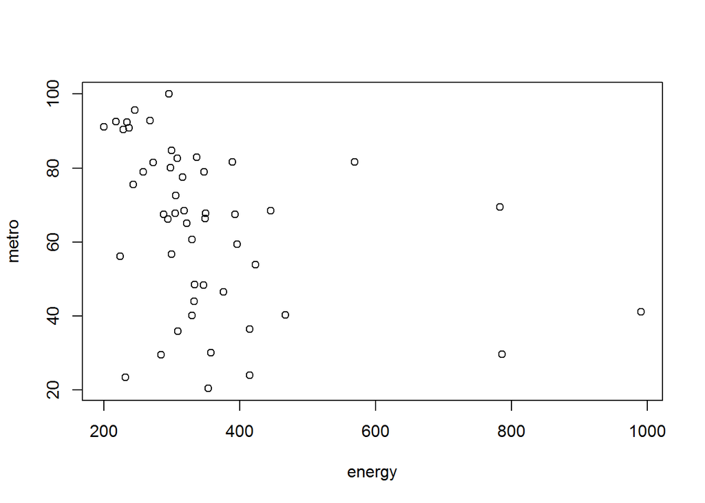

```r
plot(sts.eng.mtr)
```

### Print and interpret the model `summary’

```r
sat.eng.mod <- lm(energy ~ metro,
              data=states.data)
summary(sat.eng.mod)
```

```
##
## Call:
## lm(formula = energy ~ metro, data = states.data)
##
## Residuals:
##     Min      1Q  Median      3Q     Max
## -215.51  -64.54  -30.87   18.71  583.97
##
## Coefficients:
##             Estimate Std. Error t value Pr(>|t|)
## (Intercept) 501.0292    61.8136   8.105 1.53e-10 ***
## metro        -2.2871     0.9139  -2.503   0.0158 *
## ---
## Signif. codes:  0 '***' 0.001 '**' 0.01 '*' 0.05 '.' 0.1 ' ' 1
##
## Residual standard error: 140.2 on 48 degrees of freedom
##   (1 observation deleted due to missingness)
## Multiple R-squared:  0.1154, Adjusted R-squared:  0.097
## F-statistic: 6.263 on 1 and 48 DF,  p-value: 0.01578
```

**The R-squared is low at 0.1154. this does not look to be a very good regregression model with this data alone. There also seems to be some data points that skew the data a bit**

### `plot’ the model to look for deviations from modeling assumptions

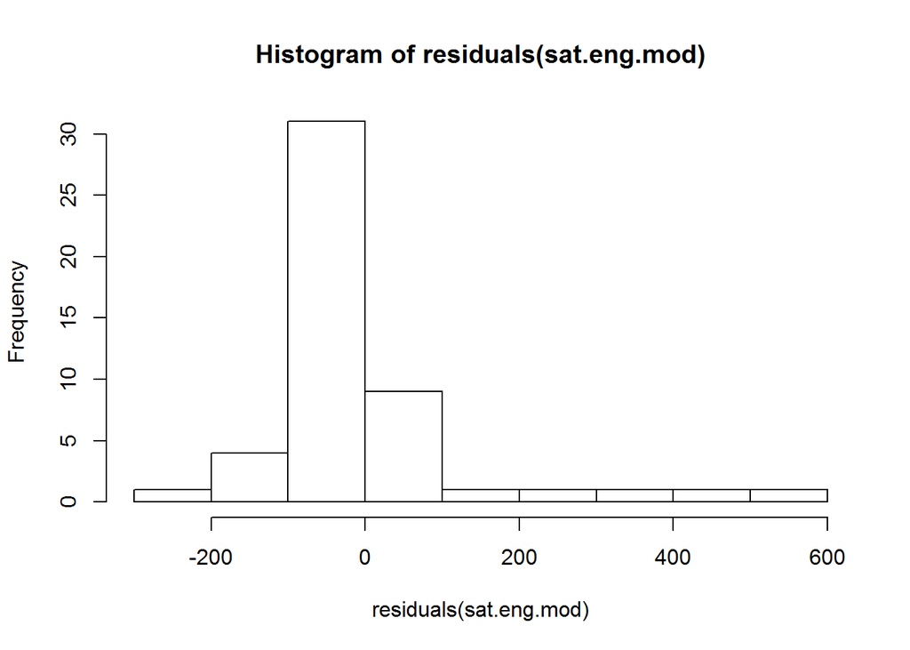

```r
hist(residuals(sat.eng.mod))
```

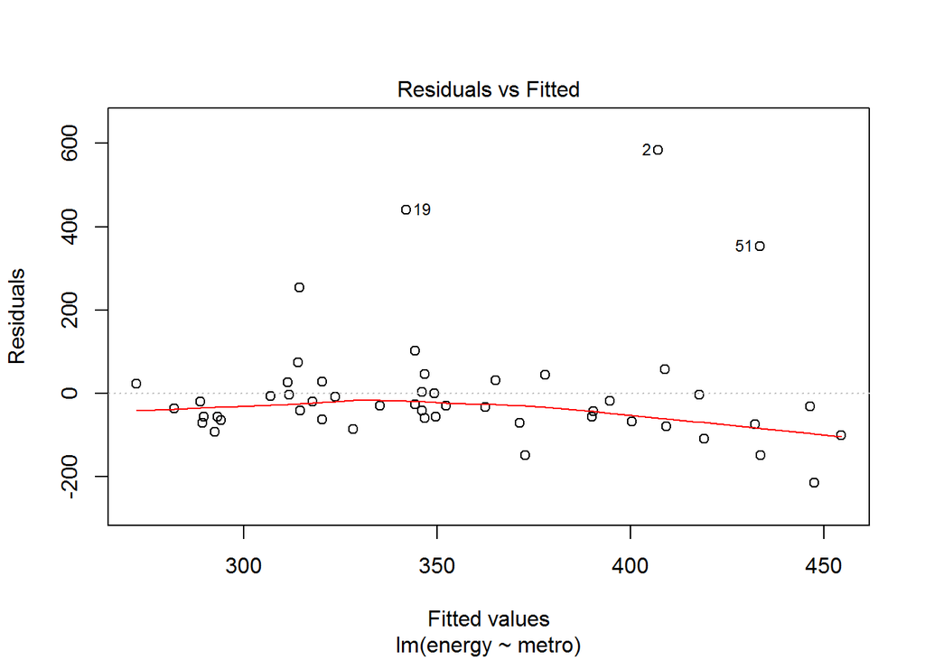

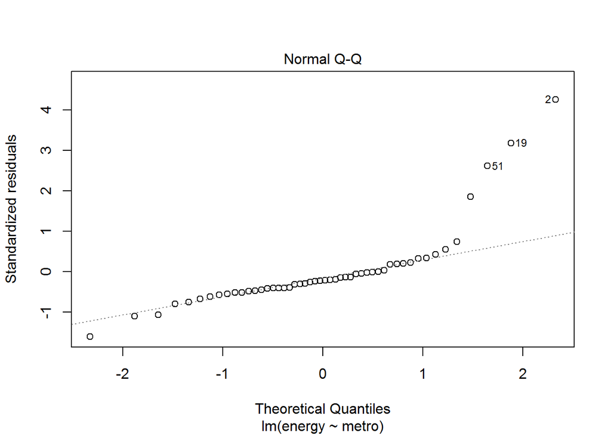

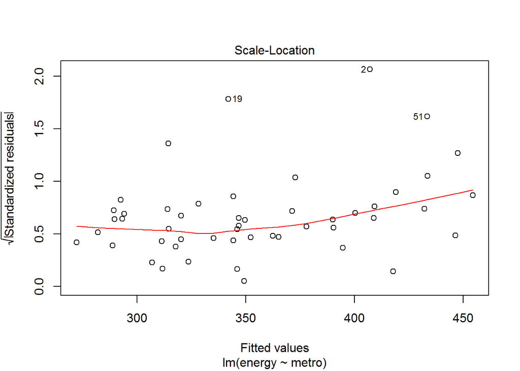

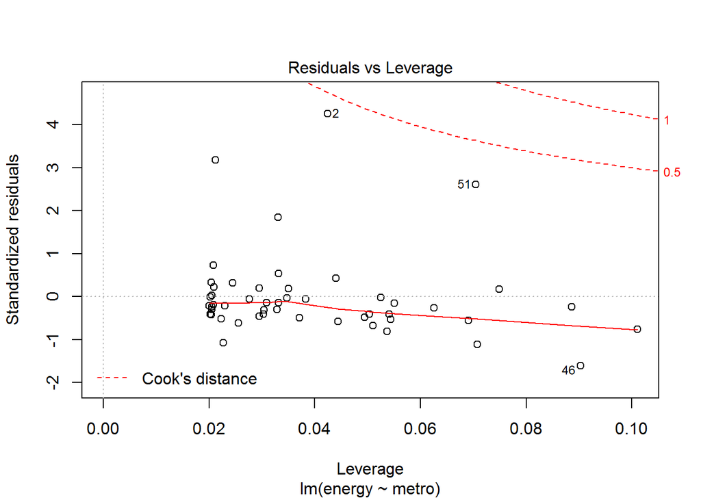

```r
plot(sat.eng.mod)
```

## With additional predictors

### Examine/plot the data before fitting the model

```r
sts.eng.hse <- subset(states.data, select = c("energy", "house"))
sts.eng.snt <- subset(states.data, select = c("energy", "senate"))
sts.eng.total <- subset(states.data, select = c("energy", "metro", "house", "senate"))
summary(sts.eng.total)
```

```
##      energy          metro            house           senate
##  Min.   :200.0   Min.   : 20.40   Min.   : 0.00   Min.   :10.00
##  1st Qu.:285.0   1st Qu.: 46.98   1st Qu.:31.00   1st Qu.:27.00
##  Median :320.0   Median : 67.55   Median :44.50   Median :51.00
##  Mean   :354.5   Mean   : 64.07   Mean   :44.82   Mean   :49.78
##  3rd Qu.:371.5   3rd Qu.: 81.58   3rd Qu.:59.25   3rd Qu.:67.00
##  Max.   :991.0   Max.   :100.00   Max.   :85.00   Max.   :97.00
##  NA's   :1       NA's   :1        NA's   :1       NA's   :1
```

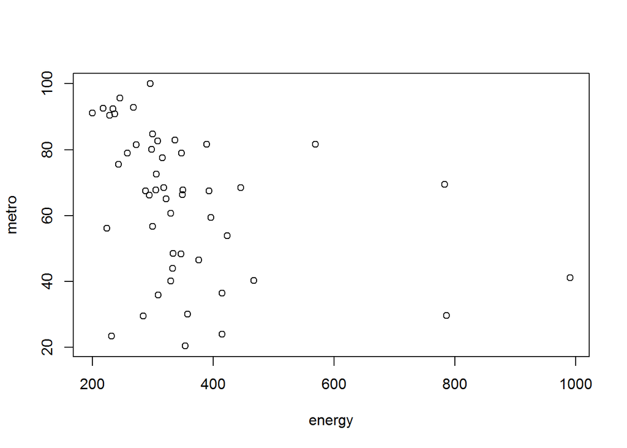

```r
plot(sts.eng.mtr)
```

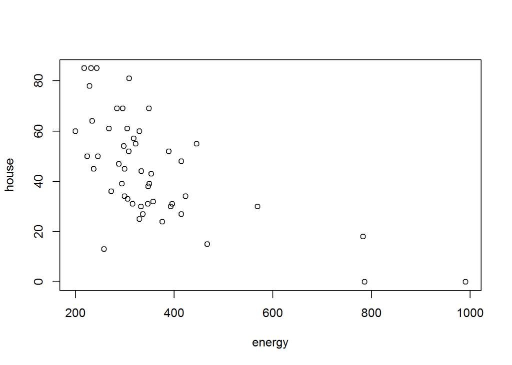

```r
plot(sts.eng.hse)
```

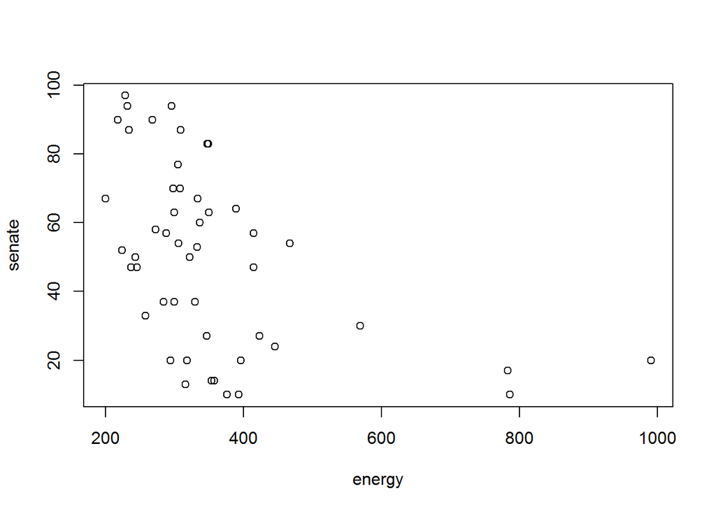

```r
plot(sts.eng.snt)
```

### Print and interpret the model `summary’

```r
sat.eng.mod2 <- lm(energy ~ metro + house + senate,
              data=states.data)
summary(sat.eng.mod2)
```

```
##
## Call:
## lm(formula = energy ~ metro + house + senate, data = states.data)
##
## Residuals:
##     Min      1Q  Median      3Q     Max
## -209.88  -69.43  -19.06   39.04  423.60
##
## Coefficients:
##             Estimate Std. Error t value Pr(>|t|)
## (Intercept) 620.7157    55.6715  11.150 1.14e-14 ***
## metro        -1.1735     0.8085  -1.451 0.153461
## house        -3.9799     1.0407  -3.824 0.000393 ***
## senate       -0.2541     0.8595  -0.296 0.768797
## ---
## Signif. codes:  0 '***' 0.001 '**' 0.01 '*' 0.05 '.' 0.1 ' ' 1
##
## Residual standard error: 114.4 on 46 degrees of freedom
##   (1 observation deleted due to missingness)
## Multiple R-squared:  0.4356, Adjusted R-squared:  0.3988
## F-statistic: 11.84 on 3 and 46 DF,  p-value: 7.197e-06
```

**The R-squared is 0.4356. this is a little bit better but we should probably continue to work on it. There still seems to be some data points that skew the data**

### `plot’ the model to look for deviations from modeling assumptions

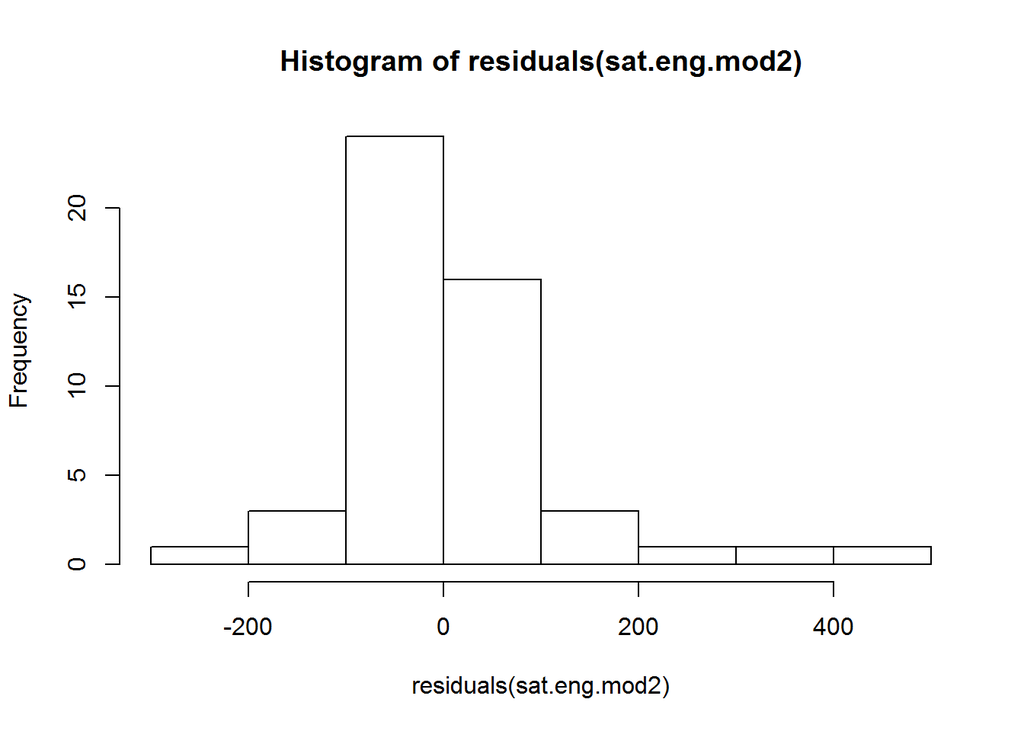

```r
hist(residuals(sat.eng.mod2))
```

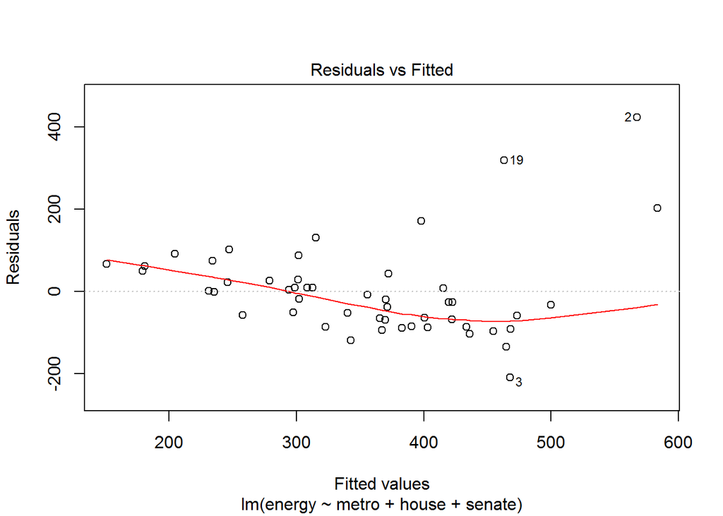

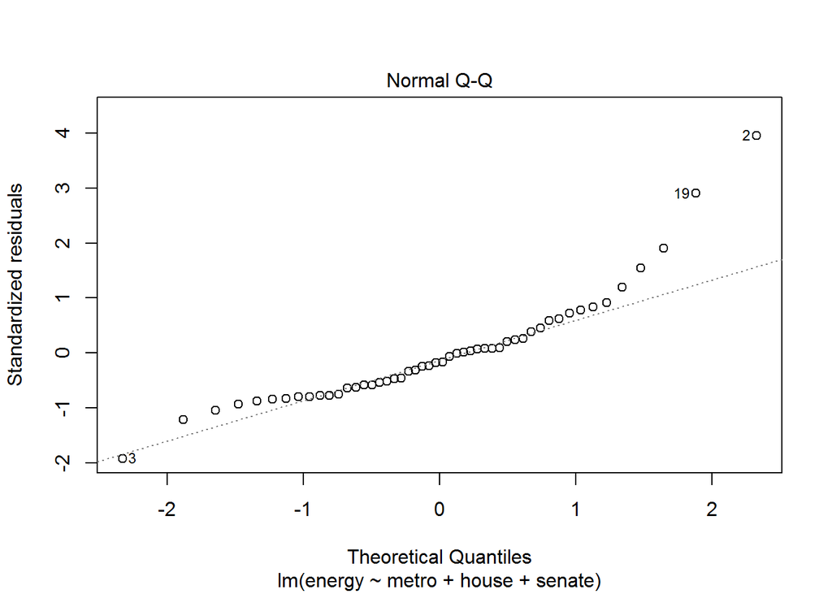

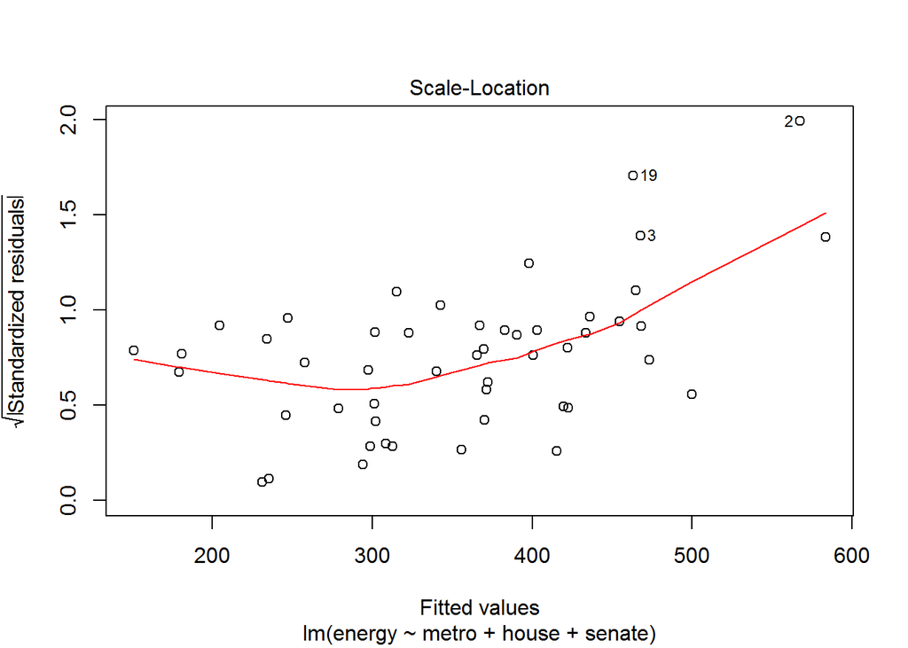

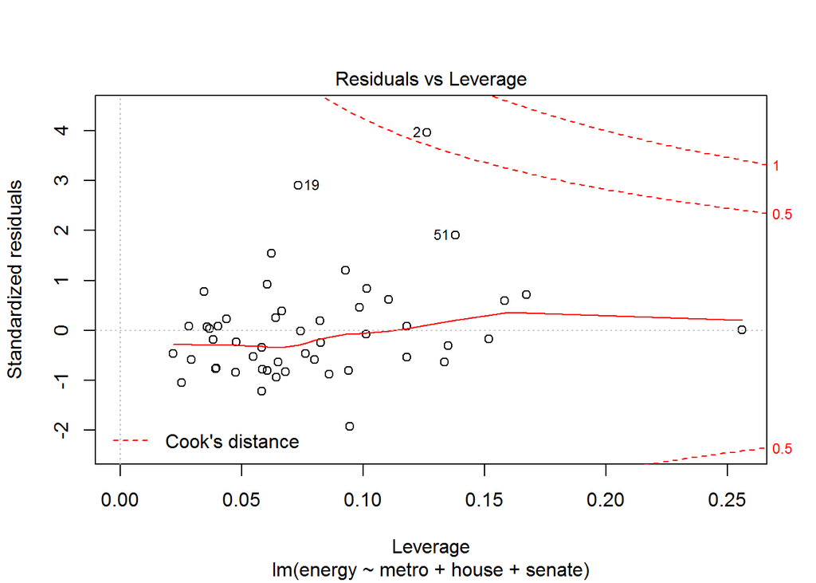

```r
plot(sat.eng.mod2)
```

# Exercise 2: Interactions and factors

Use the states data set.

1. Add on to the regression equation that you created in exercise 1 by generating an interaction term and testing the interaction.
2. Try adding region to the model. Are there significant differences across the four regions?

### Add on to the regression equation that you created in exercise 1 by generating an interaction term and testing the interaction.

```r
sat.eng.mod2a <- lm(energy ~ metro + house*senate,
              data=states.data)
summary(sat.eng.mod2a)
```

```
##
## Call:
## lm(formula = energy ~ metro + house * senate, data = states.data)
##
## Residuals:
##     Min      1Q  Median      3Q     Max
## -242.84  -54.50  -15.07   48.79  324.19
##
## Coefficients:
##               Estimate Std. Error t value Pr(>|t|)
## (Intercept)  798.28128   71.08117  11.231 1.21e-14 ***
## metro         -0.74524    0.73469  -1.014  0.31584
## house         -8.66614    1.62959  -5.318 3.17e-06 ***
## senate        -5.04231    1.56768  -3.216  0.00241 **
## house:senate   0.09438    0.02692   3.507  0.00104 **
## ---
## Signif. codes:  0 '***' 0.001 '**' 0.01 '*' 0.05 '.' 0.1 ' ' 1
##
## Residual standard error: 102.5 on 45 degrees of freedom
##   (1 observation deleted due to missingness)
## Multiple R-squared:  0.5567, Adjusted R-squared:  0.5173
## F-statistic: 14.13 on 4 and 45 DF,  p-value: 1.517e-07
```

**The regression equation did improve to 0.5567 by making the house and energy dependant on the senate**

### Add region to the model. Are there differences across the four regions?

```r
str(states.data$region)
```

```
##  Factor w/ 4 levels "West","N. East",..: 3 1 1 3 1 1 2 3 NA 3 ...
```

```r
states.data$region <- factor(states.data$region)
sat.eng.mod2b <- lm(energy ~ metro + region + house*senate,
              data=states.data)
summary(sat.eng.mod2b)
```

```
##
## Call:
## lm(formula = energy ~ metro + region + house * senate, data = states.data)
##
## Residuals:
##     Min      1Q  Median      3Q     Max
## -243.29  -44.11   -6.97   38.34  316.97
##
## Coefficients:
##                Estimate Std. Error t value Pr(>|t|)
## (Intercept)   818.01721   74.12523  11.036 5.46e-14 ***
## metro          -0.57826    0.75054  -0.770 0.445346
## regionN. East -82.72805   60.29178  -1.372 0.177308
## regionSouth    -1.45712   38.59053  -0.038 0.970059
## regionMidwest  18.75761   44.47635   0.422 0.675363
## house          -9.61870    1.73922  -5.530 1.88e-06 ***
## senate         -6.01098    1.72716  -3.480 0.001181 **
## house:senate    0.12205    0.03147   3.878 0.000364 ***
## ---
## Signif. codes:  0 '***' 0.001 '**' 0.01 '*' 0.05 '.' 0.1 ' ' 1
##
## Residual standard error: 102.4 on 42 degrees of freedom
##   (1 observation deleted due to missingness)
## Multiple R-squared:  0.5865, Adjusted R-squared:  0.5176
## F-statistic: 8.512 on 7 and 42 DF,  p-value: 1.867e-06
```

**There does not seem to be significant diferences with region added.**